# Social Network Analysis Home Assignment 4

Maria Osipova

due date - 11.06.2018 23:59

# Network Epidemics

Please send your reports to hse.ntwks@gmail.com with the subject of of the following structure:  
*[MAGOLEGO SNA 2017] {LastName} {First Name} HW{Number}*

Late submission policy: -2 points per day

Use this file as a template for your report.  
Support your computations with figures and comments. Send ONLY .Rmd versions of your report.

## SIR Model

You need to perform epidemic SIR model on different types of networks: Try different parameters for network generation

```r
gl <- list()
gl$ba <- barabasi.game(n = 100,m = 12 , directed=FALSE)
gl$er <- erdos.renyi.game(n = 250, p.or.m = 0.02, type=c("gnp"))
gl$ws <- watts.strogatz.game(dim = 1, size = 1000, nei = 3, p = 0.01)

data <- read.table("Net.txt")
data <- t(as.matrix(data))
data <- data[,c(11:20777)] # data with id = 0 leads to compilation error - making a subset without it
gl$net <- graph(data)
ev_er <- evcent(gl$er)$value
ev_ba <- evcent(gl$ba)$value
ev_ws <- evcent(gl$ws)$value
ev_net <- evcent(gl$net)$value
no.clusters(gl$er)
```

```
## [1] 3
```

```r
no.clusters(gl$ba)
```

```
## [1] 1
```

```r
no.clusters(gl$ws)
```

```
## [1] 1
```

```r
no.clusters(gl$net)
```

```
## [1] 4
```

Moreover perform modeling on real peer-to-peer network [here](https://www.hse.ru/data/2016/04/21/1130159900/Net.txt)

Your goal is to perform a research on epidemics: Use different values of parameters listed below

```r
beta <- 2
gamma <- 4
ntrials <- 100

# Running function sir for each element of list gl (list with graphs)
sim <- lapply(gl, sir, beta=beta, gamma=gamma, no.sim=ntrials)
beta1 <- 4
gamma1 <- 8
ntrials1 <- 100

# Running function sir for each element of list gl (list with graphs)
sim1 <- lapply(gl, sir, beta=beta1, gamma=gamma1, no.sim=ntrials1)
beta2 <- 6
gamma2 <- 6
ntrials2 <- 500

# Running function sir for each element of list gl (list with graphs)
sim2 <- lapply(gl, sir, beta=beta2, gamma=gamma2, no.sim=ntrials2)
beta3 <- 8
gamma3 <- 2
ntrials3 <- 1000

# Running function sir for each element of list gl (list with graphs)
sim3 <- lapply(gl, sir, beta=beta3, gamma=gamma3, no.sim=ntrials3)
```

at least 3 different versions, for example:

- betta (4 6 8)
- gamma (8 6 2)
- niter (100 500 1000)

*For some reason `beta` and `gamma` parameters should not be set below 0 and 1. Looks like they are somehow normilized during simulation.*

The code below can help you with plotting

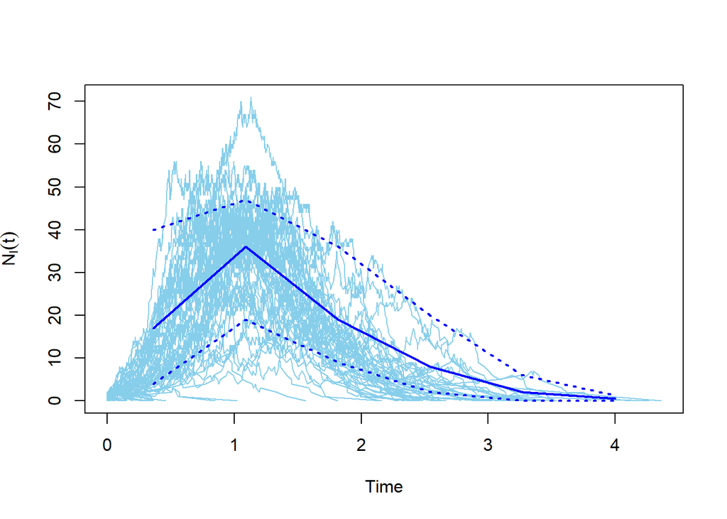

```r
# par(mfrow=c(3,1)) # combining plots
plot(sim$er)
```

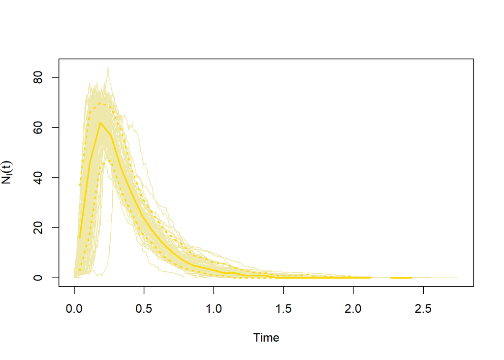

```r
plot(sim$ba, color="palegoldenrod", median_color="gold", quantile_color="gold")
```

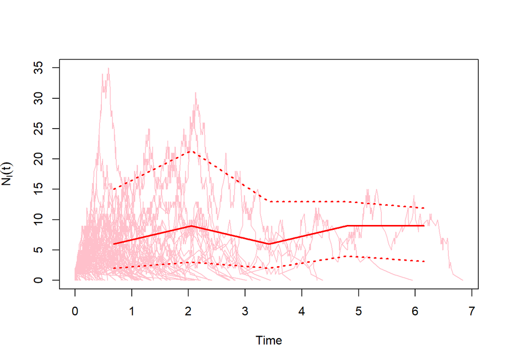

```r
plot(sim$ws, color="pink", median_color="red", quantile_color="red")
```

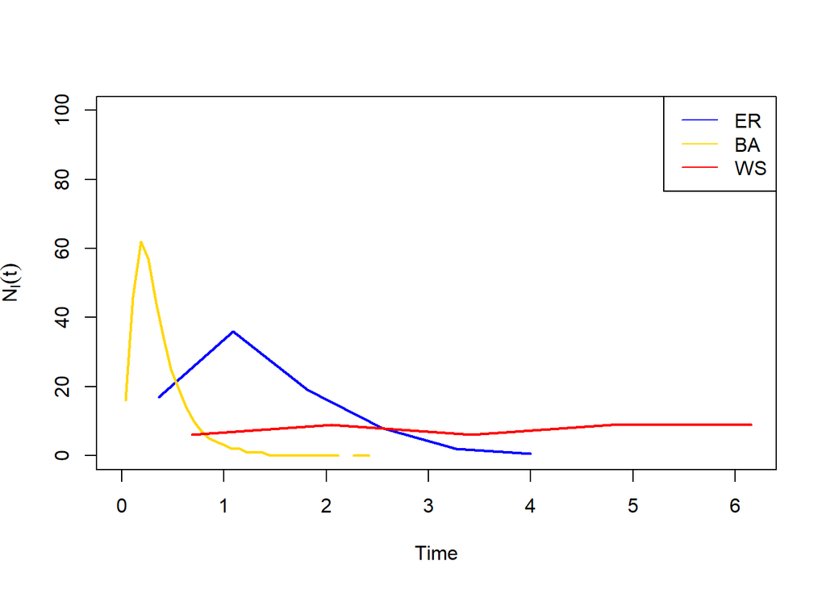

```r
x.max <- max(sapply(sapply(sim, time_bins), max))
y.max <- 1.05 * max(sapply(sapply(sim, function(x) median(x)[["NI"]]), max, na.rm=TRUE))

plot(time_bins(sim$er), median(sim$er)[["NI"]], type="l", lwd=2, col="blue", xlim=c(0, x.max), ylim=c(0, 100), xlab="Time", ylab=expression(N[I](t)))
lines(time_bins(sim$ba), median(sim$ba)[["NI"]], lwd=2, col="gold")
lines(time_bins(sim$ws), median(sim$ws)[["NI"]],lwd=2, col="red")
legend("topright", c("ER", "BA", "WS"),col=c("blue", "gold", "red"), lty=1)
```

You need to plot three values on the graphics: Number of infected, number of suseprible, number of recovered - all depends on time. As a result of this task, you need to provide 12 plots (one for each network with 3 diferent parameters) with explanation.

The main ideas of these models are: - Erdos-Renyi (ER) model: every possible edge is created with the same constant probability. - Barabasi-Albert (BA) model: each new node is connected to existing nodes with a probability proportional to the number of links of these nodes. - Watts-Strogatz (WS) model: accounts for clustering while retaining the short average path lengths of the ER model.

At the plots we see that as time increases, we get that r(t) (fraction of the population that will get sick) stabilizes and so dr/dt = 0 and lines come to 0 - common thing for all the simulations.

At the given simulation (2 4 100) for er model we see the peak, but rather small.

for ba model we see the bigger peak relatively to other plots

for ws model we don’t see peaks - this connected with the fact that only 1 cluster for this model exists (see the result of function no.clusters(gl$ws)).

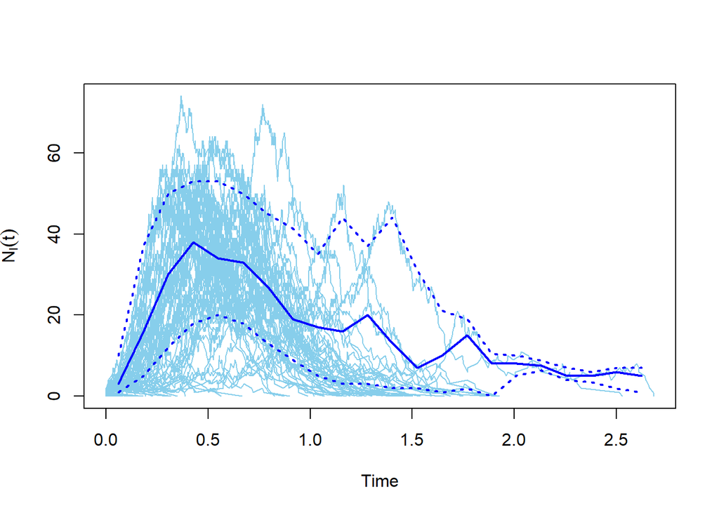

```r
# par(mfrow=c(3,1)) # combining plots
plot(sim1$er)
```

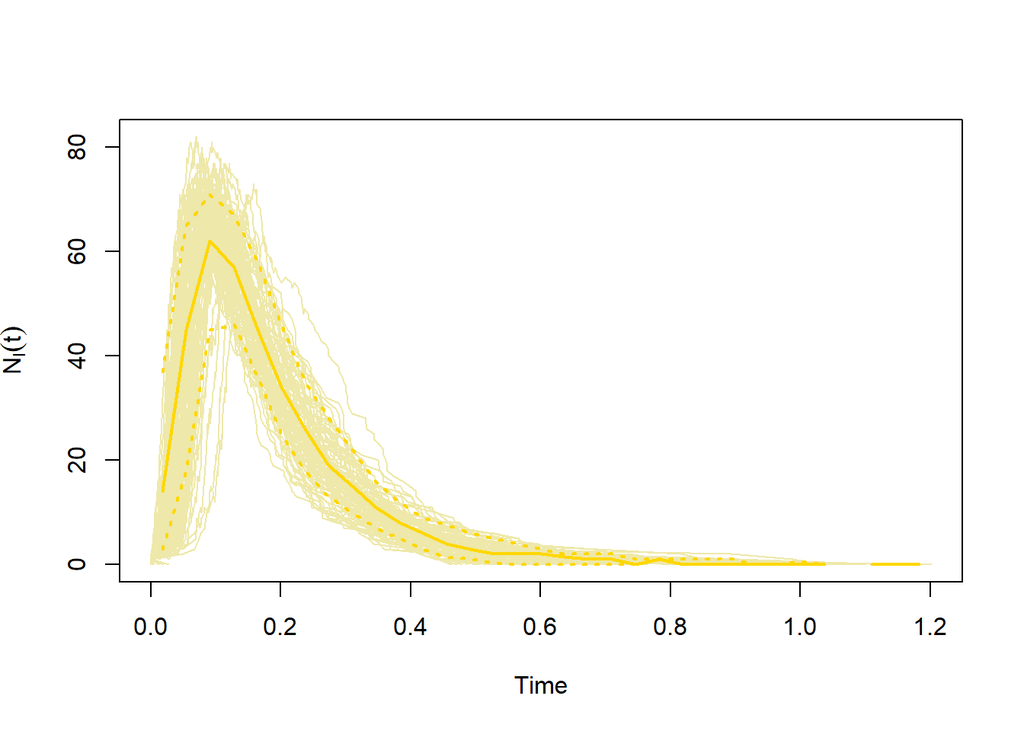

```r
plot(sim1$ba, color="palegoldenrod", median_color="gold", quantile_color="gold")
```

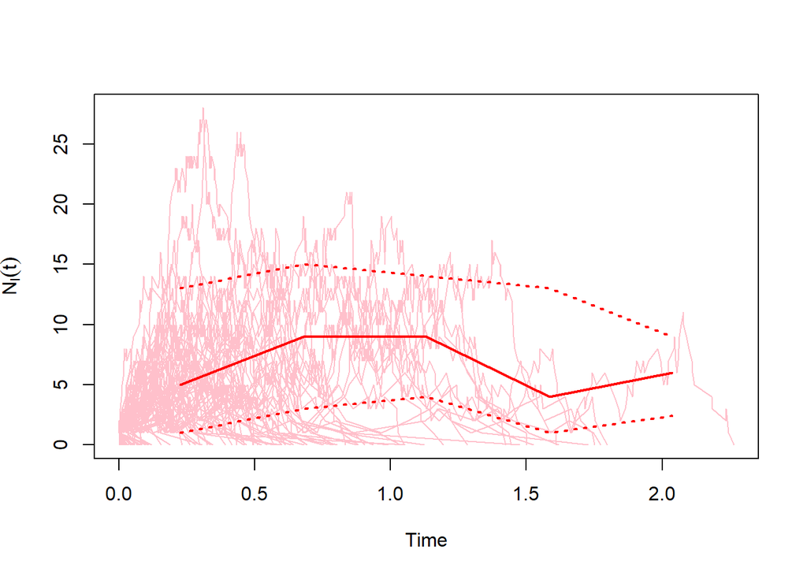

```r
plot(sim1$ws, color="pink", median_color="red", quantile_color="red")
```

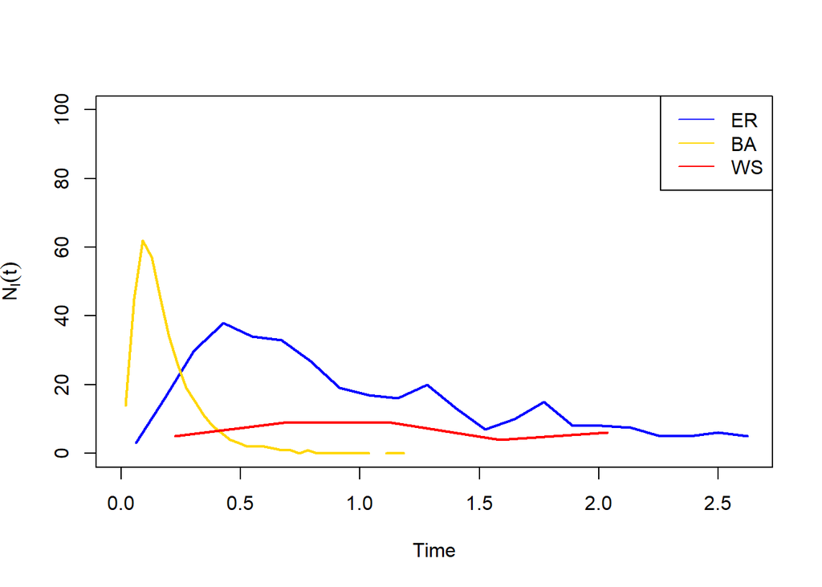

```r
x.max <- max(sapply(sapply(sim1, time_bins), max))
y.max <- 1.05 * max(sapply(sapply(sim1, function(x) median(x)[["NI"]]), max, na.rm=TRUE))

plot(time_bins(sim1$er), median(sim1$er)[["NI"]], type="l", lwd=2, col="blue", xlim=c(0, x.max), ylim=c(0, 100), xlab="Time", ylab=expression(N[I](t)))
lines(time_bins(sim1$ba), median(sim1$ba)[["NI"]], lwd=2, col="gold")
lines(time_bins(sim1$ws), median(sim1$ws)[["NI"]],lwd=2, col="red")
legend("topright", c("ER", "BA", "WS"),col=c("blue", "gold", "red"), lty=1)
```

At the given simulation (4 8 100) we see the same behaviour as at the previous simulation because of the proportion between them, but for the WS model the small peak appears and as time increases.

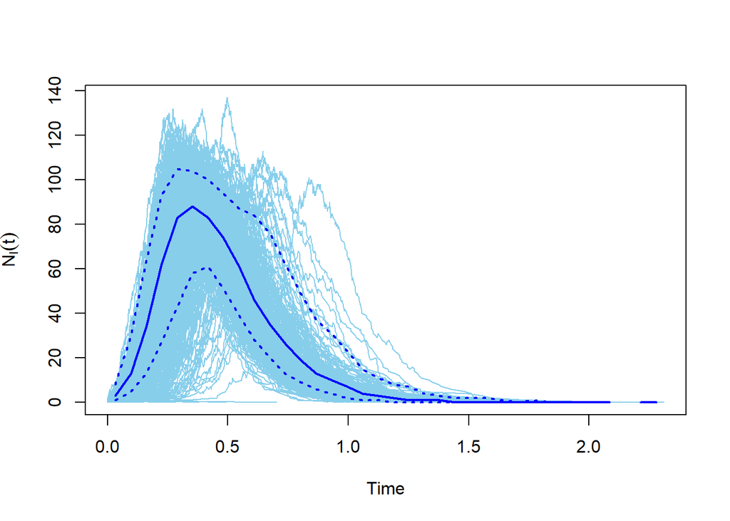

```r
# par(mfrow=c(3,1)) # combining plots
plot(sim2$er)
```

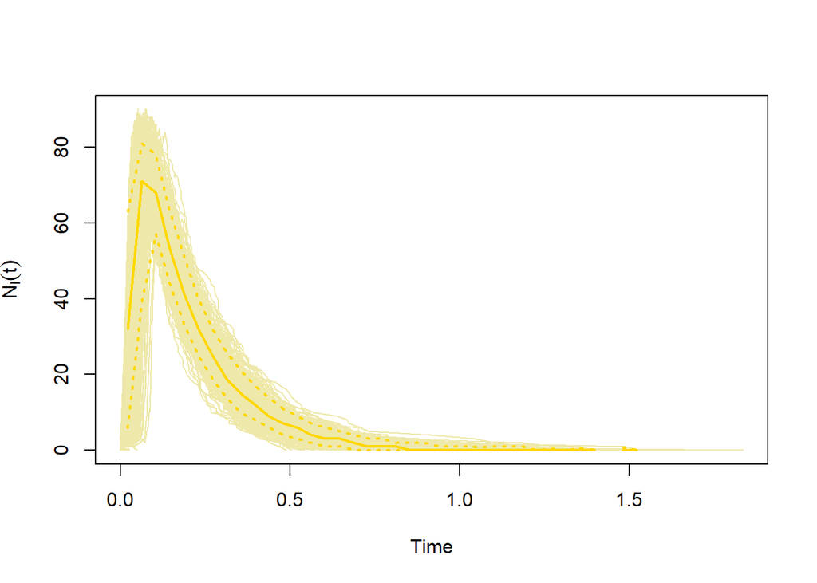

```r
plot(sim2$ba, color="palegoldenrod", median_color="gold", quantile_color="gold")
```

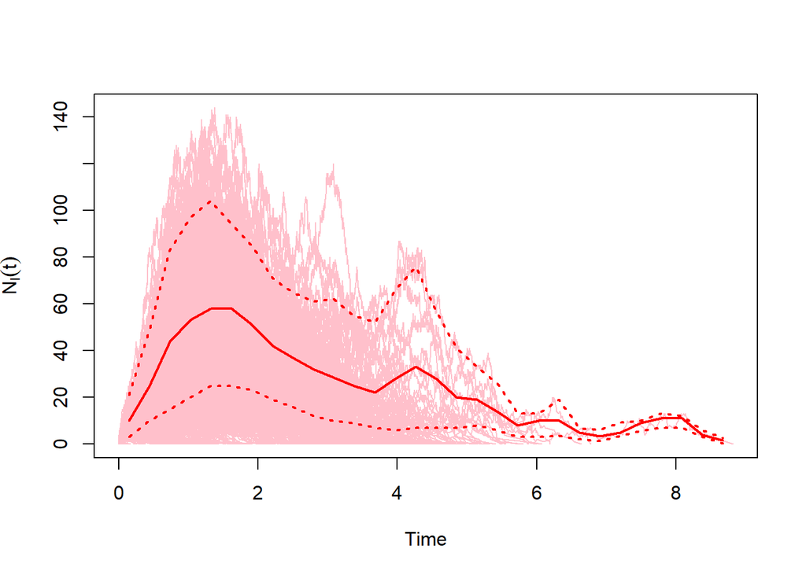

```r
plot(sim2$ws, color="pink", median_color="red", quantile_color="red")
```

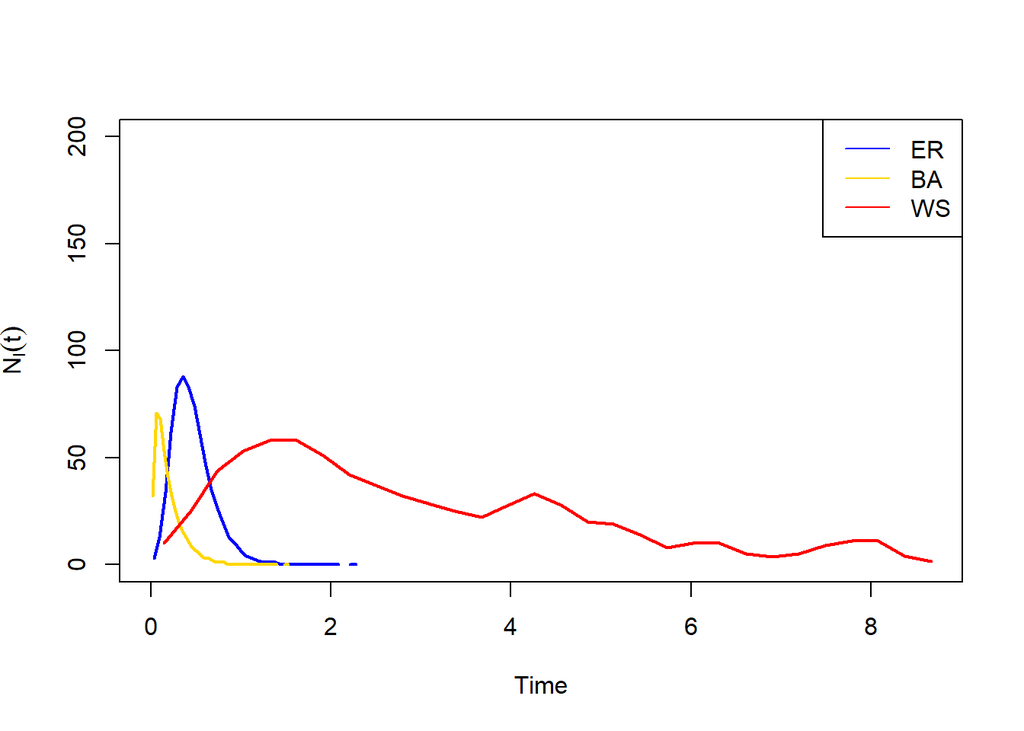

```r
x.max <- max(sapply(sapply(sim2, time_bins), max))
y.max <- 1.05 * max(sapply(sapply(sim2, function(x) median(x)[["NI"]]), max, na.rm=TRUE))

plot(time_bins(sim2$er), median(sim2$er)[["NI"]], type="l", lwd=2, col="blue", xlim=c(0, x.max), ylim=c(0, 200), xlab="Time", ylab=expression(N[I](t)))
lines(time_bins(sim2$ba), median(sim2$ba)[["NI"]], lwd=2, col="gold")
lines(time_bins(sim2$ws), median(sim2$ws)[["NI"]],lwd=2, col="red")
legend("topright", c("ER", "BA", "WS"),col=c("blue", "gold", "red"), lty=1)
```

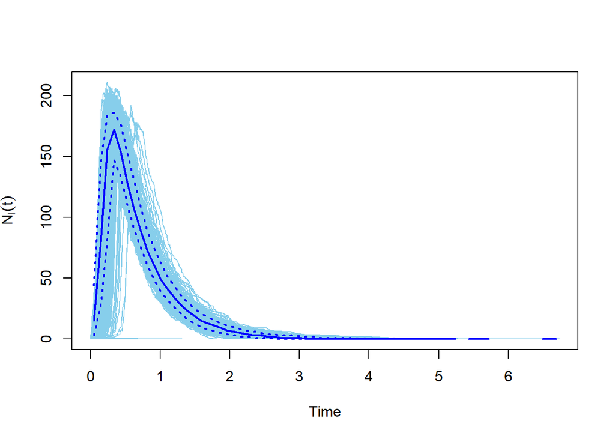

```r
# par(mfrow=c(3,1)) # combining plots
plot(sim3$er)
```

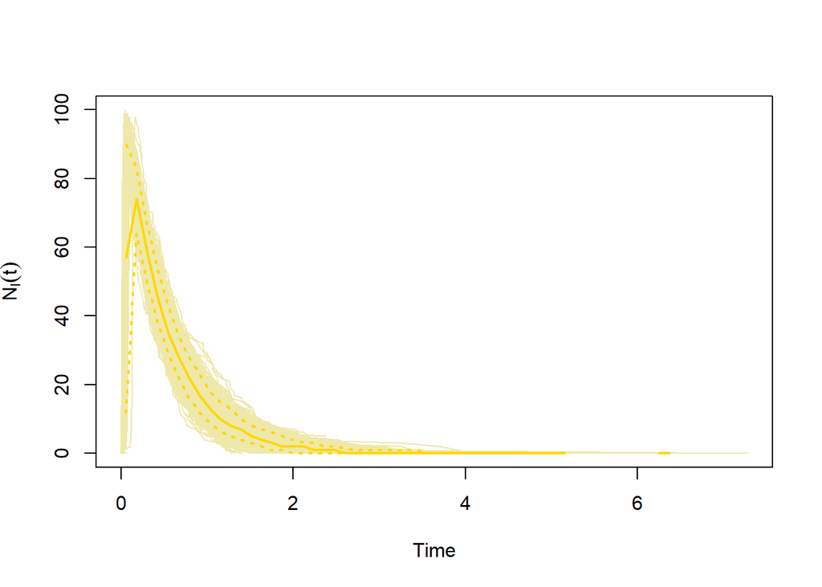

```r
plot(sim3$ba, color="palegoldenrod", median_color="gold", quantile_color="gold")
```

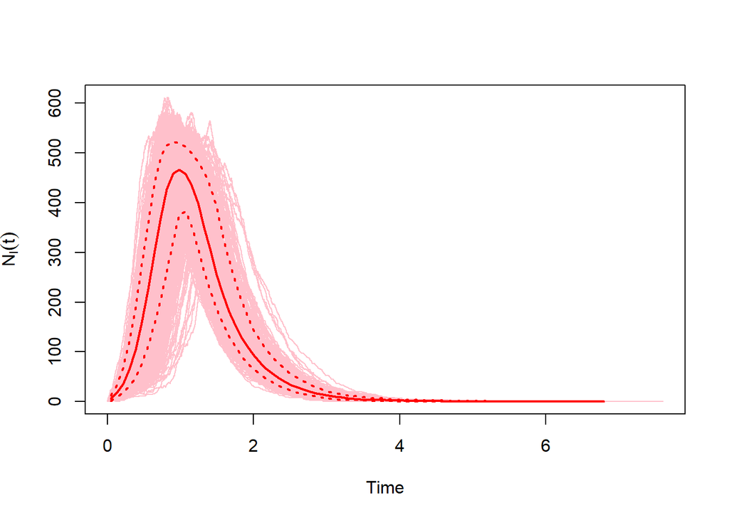

```r
plot(sim3$ws, color="pink", median_color="red", quantile_color="red")
```

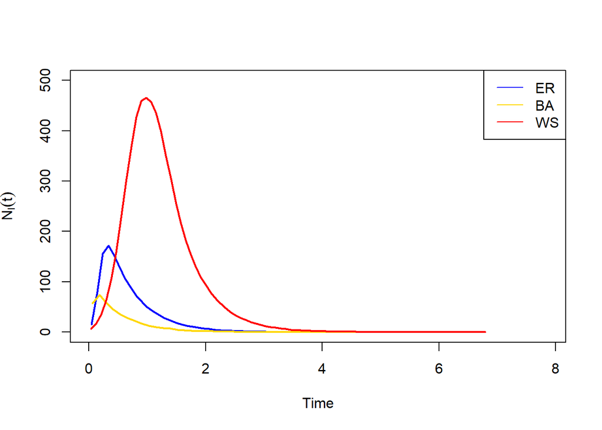

```r
x.max <- max(sapply(sapply(sim3, time_bins), max))
y.max <- 1.05 * max(sapply(sapply(sim3, function(x) median(x)[["NI"]]), max, na.rm=TRUE))

plot(time_bins(sim3$er), median(sim3$er)[["NI"]], type="l", lwd=2, col="blue", xlim=c(0, x.max), ylim=c(0, 500), xlab="Time", ylab=expression(N[I](t)))
lines(time_bins(sim3$ba), median(sim3$ba)[["NI"]], lwd=2, col="gold")
lines(time_bins(sim3$ws), median(sim3$ws)[["NI"]],lwd=2, col="red")
legend("topright", c("ER", "BA", "WS"),col=c("blue", "gold", "red"), lty=1)
```

At the given simulation (8 2 1000) because of a big value of beta parameter and small value of gamma we see the highest peaks of all the simulations and the typical coming to 0 for all the models. It connected with the formulas (ds/ dt = - beta * s * x and dx/dt = beta * s * x - gamma * x) - the big increment at the time.